# Judgment Aggregation: Prediction Market or Majority Vote?

Korbinian Friedl

The London School of Economics and Political Science

# Knowing the Future

- It sure would be nice to know the future sometimes
- I mean not just because it would be interesting, but also because it could be really helpful for taking appropriate precautions or making the necessary preparations

# Example: Horse Bad?

[figure not shown]

(Tiepolo c. 1760)

## Opinions Are Divided

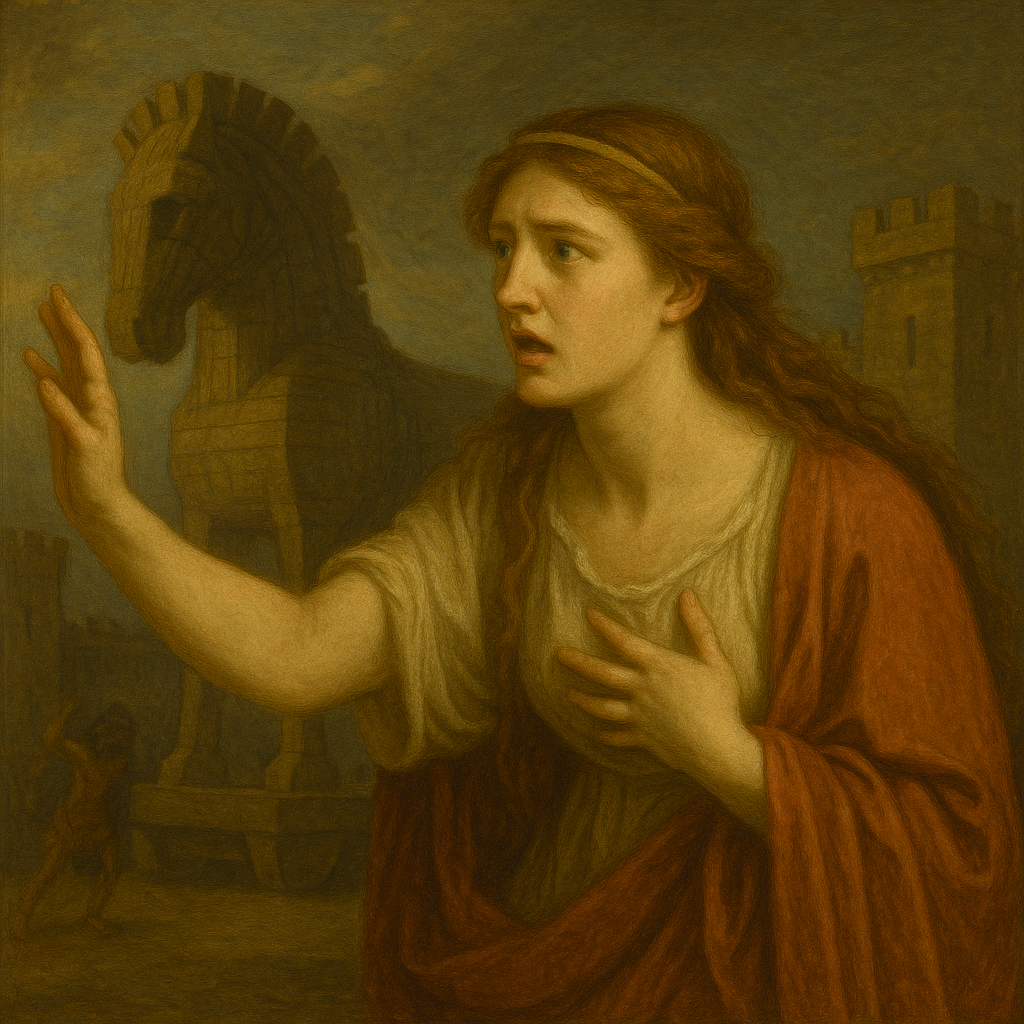

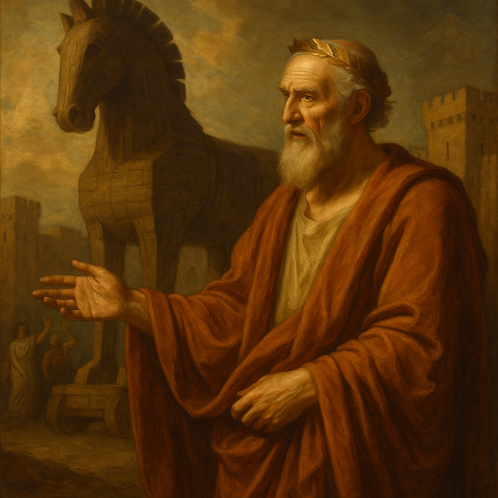

# In this Talk

- I will present theorems to the effect that (if modelled as exchange economies), prediction markets will exhibit the same advantages which the CJT certifies for majority voting
- In this sense, they are no less (and perhaps more) effective at tapping into individuals’ rationality and expertise for the purpose of getting accurate predictions
- I will end, however, by briefly discussing another result, which suggests a nuanced relationship of markets and individuals’ rationality: The perspective of the “No Trade Theorem”, which suggests that some irrationality is required for the smooth functioning of Prediction Markets

# Outline

- What is the CJT?
- Prediction Markets as Judgment Aggregators
- Modelling Prediction Markets as Exchange Economies
- Jury Theorems for Prediction Markets
- The Perspective of the “No Trade Theorem”

# What is the CJT and What Are Prediction Markets

(Sadly, the fun part of the talk is over now, and we are now entering the drudgery of some very formal results)

## General Setting

- We have a proposition $q$, and a population of $n$ agents (assume $n$ odd for simplicity)
- The truth value of $q$, $\varphi(q)\in\{0,1\}$, is as of yet unknown
- Denote the beliefs the agents hold about $q$ with $B_1(q), \ldots, B_n(q)$
- Let $V(q) \in \{0,1\}$ be the result of a majority vote taken among the agents

## Assumptions Required for the CJT

- **Competence**: Each agent has a better-than-chance probability $r>\frac{1}{2}$ of getting it right — $\mathbb{P}(B_i(q) = x \mid \varphi(q)=x)=r>\frac{1}{2}$
- **Independence**: Agents’ beliefs are stochastically (mutually) independent, conditional on the state of the world
- **Sincerity**: Every agent casts their vote in accordance with what they truly believe. I.e. $V(q)=1$ iff $\# \{i \mid B_i(q)=1 \} > \# \{i \mid B_i(q) = 0 \}$

## Theorem 1 (Condorcet Jury Theorem)

For each possible truth value of $q$, $x \in \{0, 1\}$, the probability of a correct majority vote $\mathbb{P}(V(q)=x \mid \varphi(q)=x)$

- is greater than each individual’s probability of having the correct belief $\mathbb{P}(B_i(q)=x \mid \varphi(q)=x)=r$ (“non-asymptotic result”), and
- converges to 1 as the number of participating individuals increases (“asymptotic result”)

## Another Example

- Imagine we are wondering: How much are sea levels going to rise due to climate change?
- Answers to this question might have policy implications—e.g. do we need extra flood protection measures in Groningen?
- If we have a pool of experts on climate change and sea levels, each of which have a $>50\%$ chance of getting it right, then the CJT suggests that it might be a good idea to base our overall assessment of the question on the majority opinion of those experts

… would it also be a good (or perhaps even better) idea to use prediction markets?

## Prediction Markets

- A prediction market on $q$ is a market trading bets on $q$ and $\neg q$
  - Let $b_q$ be an asset that pays out €1 if $q$ and €0 if $\neg q$ (and vice versa for $b_{\neg q}$)
  - Let $p_q$ and $p_{\neg q}$ denote the equilibrium prices of these assets

## Prediction Markets as Judgment Aggregators

- Let $M(q) = \chi(p_q > p_{\neg q})$ denote “the market’s judgment”: It affirms $q$ iff the market price of a bet on $q$ is higher than the market price of a bet on $\neg q$

## Example

[figure not shown]

(Polymarket 2025)

# Modelling Prediction Markets as Exchange Economies

## Why this Framework?

- Economists use it as a simple but powerful baseline model of an economy
- Gives us a market price for $b_q$ and $b_{\neg q}$ as a function of individuals’ epistemic states—exactly what we need if we want something analogous to the CJT

## Exchange Economy

An **exchange economy** is an economy in which there are $k$ commodities and $n$ consumers $\{1, \ldots, n\}$, where each consumer $i$ is described by

- a utility function $U^i\left(x^i_1, \ldots, x^i_k\right)$, assigning a non-negative real number to each possible consumption bundle
- an initial endowment of commodities $\varpi^i = \left(\varpi^i_1, \ldots, \varpi^i_k\right) \in \mathbb{R}_{\geq 0}^k$

A **consumption bundle** for consumer $i$ is a tuple of quantities of the commodities in the economy, $x^i=\left(x^i_1, \ldots, x^i_k\right) \in \mathbb{R}^k_{\geq 0}$

An **allocation** $x=\left(x^i, \ldots, x^n\right) \in \left(\mathbb{R}^k_{\geq 0}\right)^n$ assigns a consumption bundle to each consumer

An allocation $x$ in an exchange economy with initial endowments $\varpi^1, \ldots, \varpi^n$ is **feasible** if
$$\forall l \in \{1, \ldots, k\}: \sum_{i=1}^n x^i_l \leq \sum_{i=1}^n \varpi^i_l$$

## Walrasian Equilibrium

A **Walrasian Equilibrium** in an exchange economy is a pair $\left(\bar{x}, \bar{p}\right)$, consisting of an allocation $\bar{x} = \left(\bar{x}^1, \ldots, \bar{x}^n\right)$ and a price vector $\bar{p} = \left(\bar{p}_1, \ldots, \bar{p}_k\right)$ such that:

- $\bar{x}^i$ maximizes $U^i\left(x^j\right)$ subject to $\bar{p}\cdot \bar{x}^i \leq \bar{p} \cdot \varpi^i$
- $\bar{x}$ is feasible

# Jury Theorems for Prediction Markets

## Filling in the Remaining Modelling Assumptions

- **Utility function**: $U^i(x^i_q, x^i_{\neg q})=B_i(q)x^i_q + (1 - B^i(q))x^i_{\neg q}$
- **Endowment**: Let every agent initially be endowed with one $b_q$ and one $b_{\neg q}$ (i.e. one euro)

# Jury Theorems for Prediction Markets

## Theorem 2 (PMJT for Agents with Binary Beliefs)

Under the above assumptions, and assuming $B_i(q) \in \{0,1\}$:

For each possible truth value of $q$, $x \in \{0, 1\}$, the probability of a correct market judgment $\mathbb{P}(M(q)=x \mid \varphi(q)=x)$

- is greater than each individual’s probability of having the correct belief $\mathbb{P}(B_i(q)=x \mid \varphi(q)=x)=r$ (“non-asymptotic result”), and
- converges to 1 as the number of participating individuals increases (“asymptotic result”)

## Theorem 3 (PMJT for Agents with Degrees of Belief)

- What happens if we let $B_i(q)$ take values in the interval $[0,1]$ instead of just in the set $\{0,1\}$?
- Issue: How to translate the competence assumption?
- Setting that question aside for now, we get the preliminary result that:

The market affirms $q$ iff the *median credence* is higher than 0.5, and $\neg q$ otherwise. That is, the market affirms the correct proposition iff the median credence is on the correct side of the 0.5 mark

## Can We Recover the Condorcet Properties in this Case?

We recover both properties if we assume what (Wollesen forthcoming) calls “minimal fidelity of credences”: Agents’ credences are drawn from a distribution on $[0,1]$ whose *median* is on the correct side of the 0.5 mark

## Corollary 4 (Condorcet-Like Property for PM, Degrees of Belief)

If minimal fidelity of credences is satisfied:

For each possible truth value of $q$, $x \in \{0, 1\}$, the probability of a correct market judgment $\mathbb{P}(M(q)=x \mid \varphi(q)=x)$

- is greater than each individual agent’s probability of having a credence on the correct side of 0.5, $\mathbb{P}(\mid B_i(q) - x\mid < 0.5 \mid \varphi(q)=x)$ (“non-asymptoticic result”) and
- converges to 1 as the number of agents increases (“asymptoticic result”)

# The Perspective of the “No Trade Theorem”

Consider an economy like the one we have been discussing. But assume that agents

- are risk-averse,
- have common knowledge of each other’s rationality
- have non-extreme credences
- and only accept trades that in (their) expectation don’t decrease their utility

Then no trade takes place.

# Conclusion

- Prediction Markets have similar positive properties to majority voting
- Unlike majority voting, they don’t have to rely on agents’ sincerity
- But they have to be paid for in the following sense: Someone needs to enter into not fully rational trades

# References

Polymarket. 2025. “Will 2025 Be the Hottest Year on Record?” https://polymarket.com/event/will-2025-be-the-hottest-year-on-record?tid=1755178493972.

Tiepolo, Giovanni Domenico. c. 1760. “The Procession of the Trojan Horse into Troy.” Painting. Oil on canvas. https://www.nationalgallery.org.uk/paintings/giovanni-domenico-tiepolo-the-procession-of-the-trojan-horse-into-troy.

Wollesen, Bele. forthcoming. “The Condorcet Jury Theorem Under Ambiguity.” *Ergo, an Open Access Journal of Philosophy*, forthcoming. https://www.belewollesen.com/uploads/1/4/4/0/144061730/cjt_ambiguity_accepted_not_final_version.pdf.